# Dirty Data: PDFs

Andrew Ba Tran

7/26/2019

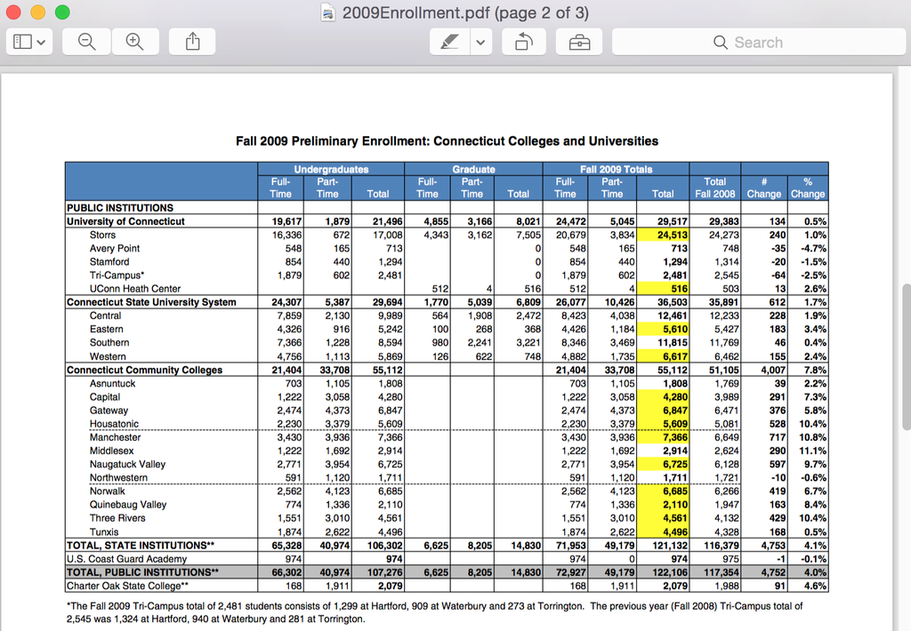

If you’re lucky, you can select the table from the PDF and copy and paste it over to another sheet.

If that works, great!

But sometimes the format gets wonky.

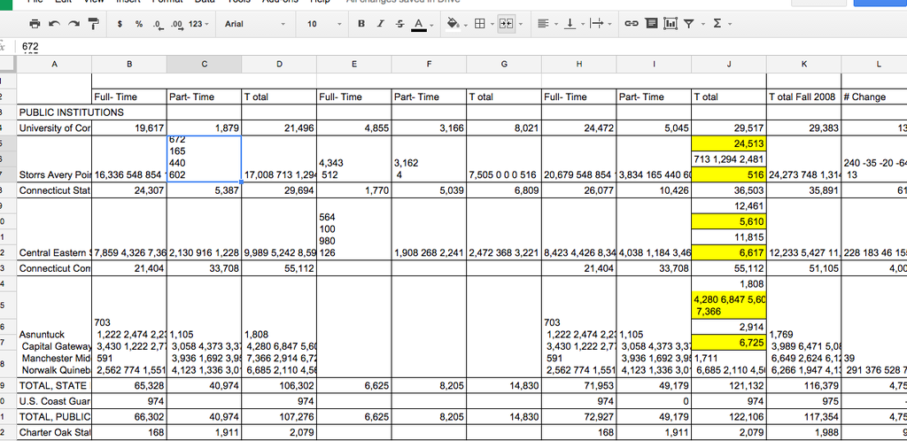

Fortunately, people have been working on ways to free data trapped in PDFs.

- **Tabula** Extract Tables from PDFs
- **Nitro** | Edit PDF, Sign & Share Digital Documents
- **Cometdocs**

All the options above are popular choices but have pros and cons.

## [Tabula](https://tabula.technology/)

**Pros**: No limit to amount of documents, allows control of what section of the PDF to select/download. Can create templates.

**Cons**: Really slow. If many people using it on the same IP can create a bottleneck.

## [Nitro](https://www.gonitro.com/)

**Pros**: Fast

**Cons**: Faster for people who pay. Honestly, I don’t use this. I use the option below.

## [Cometdocs](https://www.cometdocs.com/)

**Pros**: Fast, multiple output options like Excel, Word, etc.

**Cons**: A limited amount of PDFs allowed to be converted a month.

However, if you’re a member of IRE, you can get a free upgraded account. I recommend you go that route.

#### Go to Cometdocs and [sign up](http://www.cometdocs.com/user/login).

Go ahead and [create an account](http://www.cometdocs.com/user/login).

[figure not shown]

This is the main page. There are four tabs in the middle:

- Convert
- Transfer
- Store
- Host

Above that is the area you can upload PDFs.

Download these 3 files and upload them into Cometdocs (right click and save as to your computer).

- 2009Enrollment.pdf
- 2010Enrollment.pdf
- 2011Enrollment.pdf

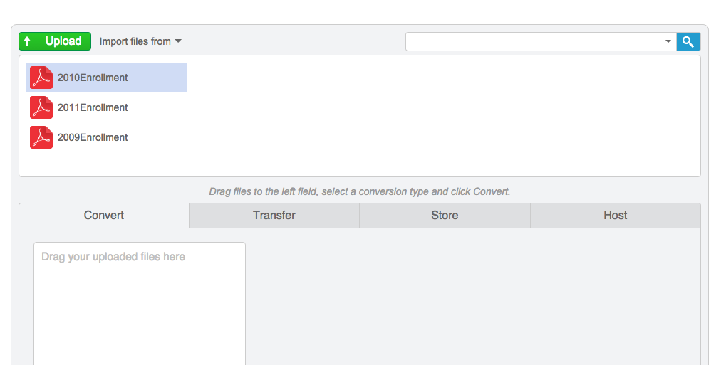

The files are now in the staging area.

Click on the **Convert tab** and drag each file from the staging area into the **Convert box**.

[figure not shown]

Select to Excel (xlsx) and then click the Convert button on the right.

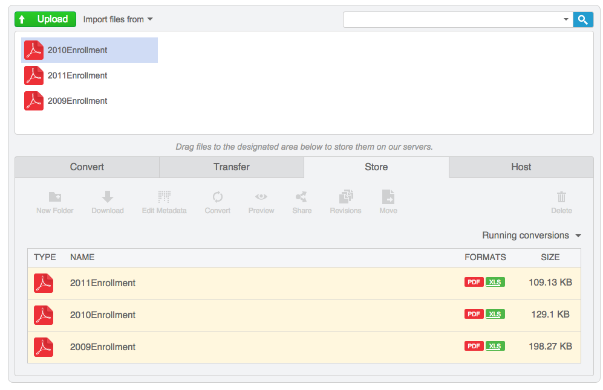

It will switch to the **Store** tab and a bar will move under the **XLS** button until it stops.

That means it’s ready to download.

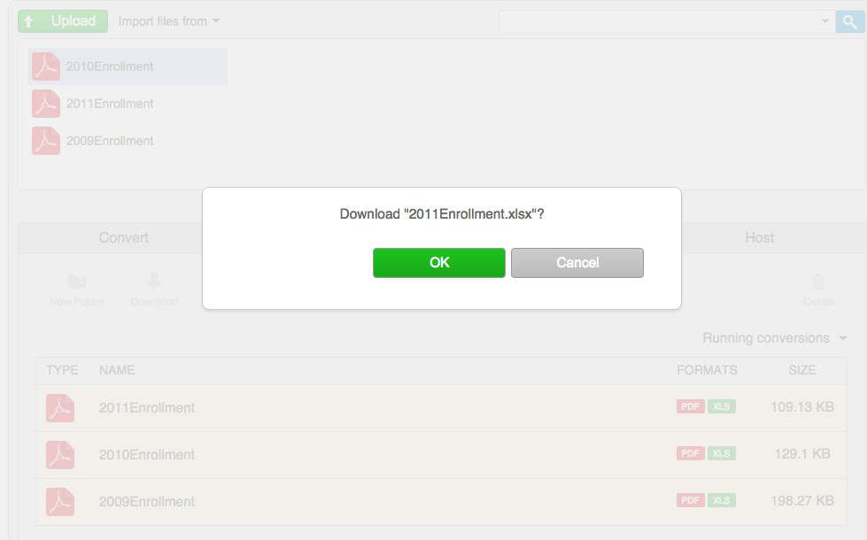

Click to download and go back and download the rest of the spreadsheets.

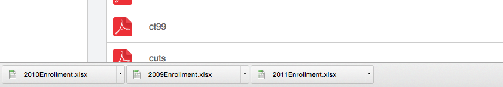

Bring the files into Excel or Google Sheets.

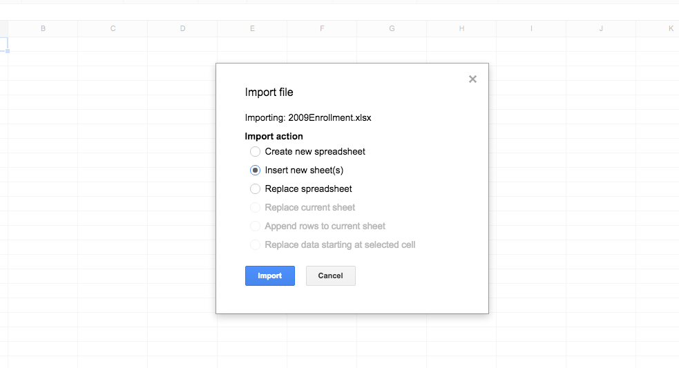

OK, looks like it worked. But now it will require some massive cleaning up.

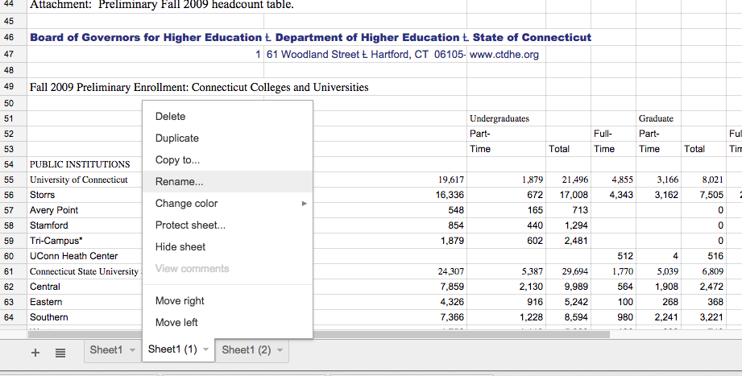

Rename the sheets to **2009**, **2010**, **2011** and also delete any blank sheets.

We need to be organized.

OK, let’s get rid of all rows with extraneous rows.

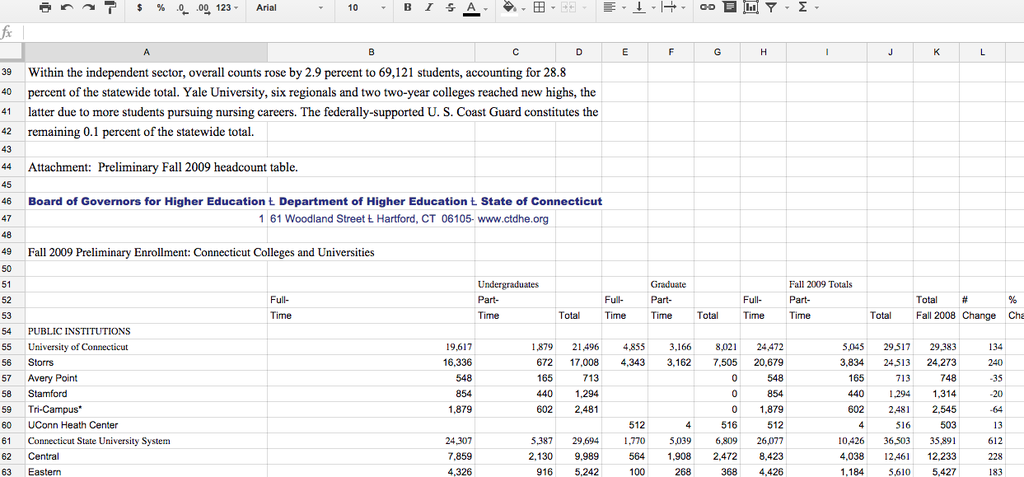

We’ve now reached the point of organizing data. What we do next depends on what we want to do with the data.

You can always refer to the original PDFs to see the way the structure is laid out.

We have three years worth of data on college enrollment.

For each sheet, the colleges are sub categorized by what system they are a part of. There’s also separate data for subtotals, totals, and Coast Guard.

There are many ways to visualize this data.

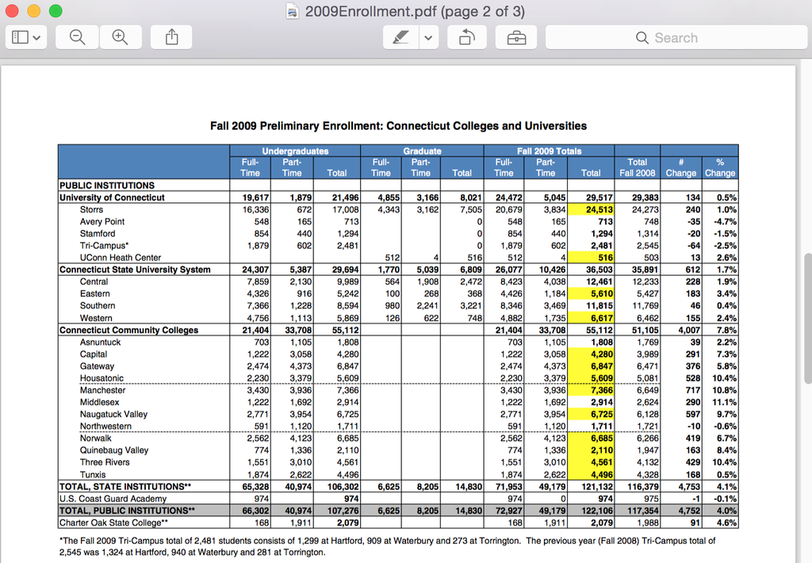

Let’s start simple.

To do this, we need to pull out the data and put it into a separate sheet.

First, create a new sheet at the bottom.

Name it CSUS

Copy and paste the names of the colleges we’re focusing on over into the new sheet:

- Central
- Eastern
- Southern
- Western

Leave a space in the first row so you can name that Connecticut State University System. We have to stay organized.

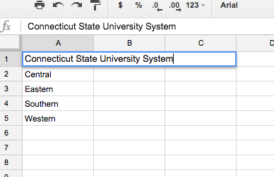

Find the data that matches the 2009 total enrollment figures (Look at the PDF if you need help narrowing it down)

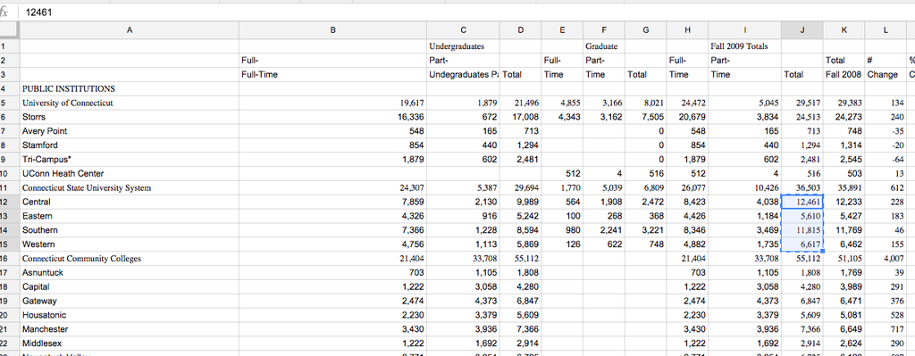

Copy and paste those numbers into the CSUS sheet next to the school name.

Leave a space in the first row so you can name that 2009.

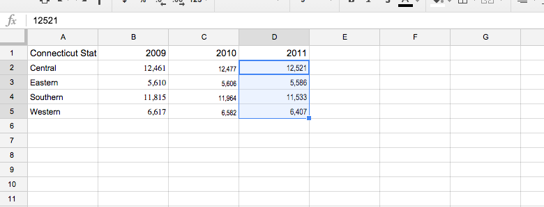

Here’s a quick new trick from Google Spreadsheets.

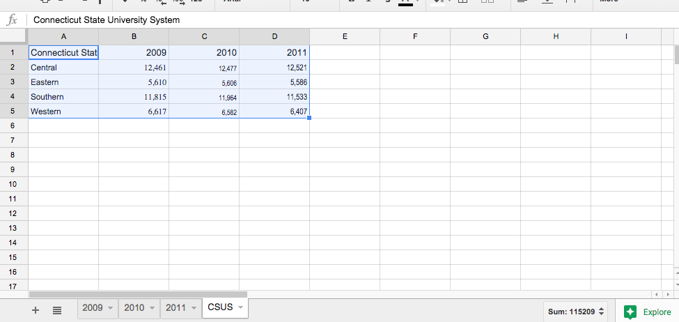

Select all the data you’ve got and click on the bottom right plus button that says **Explore**.

[figure not shown]

It will pop open a window of preliminary analysis of the data.

[figure not shown]

You can see what sort of options you have for visualizing the data.

In this example, it won’t work well because Google Sheets is interpreting 2009, 2010, 2011 as numbers that instead of headers.

**For fun, take it over to [Datawrapper.de](https://www.datawrapper.de/) and make a cool visualization**